# vbhavya_OriginalHomeworkCode_01

Bhavya Deepti Vadavalli

2023-09-16

# Homework 1 for AN/BI 588: Push It!

The goal of the homework is to demonstrate our knowledge and understanding of using an intergrated version of RStudio and Github in a collaborative way

For this, we need to follow the following steps:

1. Create a Github repo called AN588-Week-2-BUlogin (Here’s the link to mine! https://github.com/bhavya-dv/AN588-Week-2-vbhavya)

Make your group members and Chris a collaborator on the repo. The group members will share comments about your work and you will do the same. This is an exercise in sharing your work with others.

2. Create a new project on RStudio, and connect the repo from Github to RStudio. We have already done these steps in Module 3, Step 4, Version 1. Link here: https://fuzzyatelin.github.io/bioanth-stats/module-03/module-03.html#Step_4,_version_1_-_Creating_a_new_R_project_by_cloning_a_remote_repository_on_GitHub
3. Make an RMarkdown file with the challenges from Module 3. Push it! and wait for your peers to share their comments.

## Challenge 1

Goal: To make a vector of 1-word character strings with words from the first sentence in James Joyce’s Ulysses. Then, extract every third element from the vector.

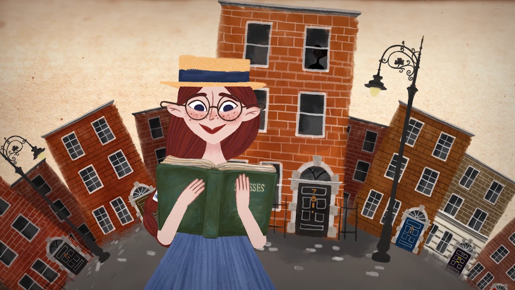

```
The above graphic is meant to be part of the prettification challenge!
```

To achieve the goals of Challenge 1, I used the function seq(), which uses a general sequence (named ulysses, in our case) and gives a subsequence which can be in increments of the general sequence. This is what we’re doing here. We are asking the seq() function to go through the 1st to 22nd elements of “ulysses” and give us a subset which is every third increment of the original vector.

```r
#creating a vector with the sentence
ulysses <- c("Stately",",","plump","Buck","Mulligan","came","from","the","stairhead",",","bearing","a","bowl","of","lather","on","which","a","mirror","and","a","razor","lay","crosed",".")

#removing all punctuation
ulysses <- gsub("[[:punct:]]","",ulysses) #replaces punctuation with empty string?

library(stringi) #stri_remove_empty(), used below, is in package stringi
ulysses <- as.character(stri_remove_empty(ulysses, na_empty = FALSE)) #removes empty strings from a vector
ulysses #ulysses is now a vector with no punctuation
```

```
##  [1] "Stately"   "plump"     "Buck"      "Mulligan"  "came"      "from"
##  [7] "the"       "stairhead" "bearing"   "a"         "bowl"      "of"
## [13] "lather"    "on"        "which"     "a"         "mirror"    "and"
## [19] "a"         "razor"     "lay"       "crosed"
```

```r
req_ul <- ulysses[seq(from = 1, to = 22, by = 3)] #the required set of every third string

req_ul
```

```
## [1] "Stately"  "Mulligan" "the"      "a"        "lather"   "a"        "a"
## [8] "crosed"
```

## Challenge 2

Goal: to create a n x m matrix using the matrix() function, where n = nrow, m = ncol, and populate it with numbers from 1 to 80. Then, extracting the mentioned, rows, columns and specific elements and assigning them to a variable x.

It is important to note that usually, matrices in R are filled by column first.

Note: the outputs when extracting rows and columns from matrices are also matrices. However, in the third case, we get a list of elements as an output. This is due to the nature of the command given.

```r
m <- matrix(data = 1:80, nrow = 8, ncol = 10, byrow = FALSE) #creating the matrix
m
```

```
##      [,1] [,2] [,3] [,4] [,5] [,6] [,7] [,8] [,9] [,10]
## [1,]    1    9   17   25   33   41   49   57   65    73
## [2,]    2   10   18   26   34   42   50   58   66    74
## [3,]    3   11   19   27   35   43   51   59   67    75
## [4,]    4   12   20   28   36   44   52   60   68    76
## [5,]    5   13   21   29   37   45   53   61   69    77
## [6,]    6   14   22   30   38   46   54   62   70    78
## [7,]    7   15   23   31   39   47   55   63   71    79
## [8,]    8   16   24   32   40   48   56   64   72    80
```

```r
#extracting the 2nd, 3rd, and 6th columns
x <- m[,c(2,3,6)]
x
```

```
##      [,1] [,2] [,3]
## [1,]    9   17   41
## [2,]   10   18   42
## [3,]   11   19   43
## [4,]   12   20   44
## [5,]   13   21   45
## [6,]   14   22   46
## [7,]   15   23   47
## [8,]   16   24   48
```

```r
#extracting the 6th and 8th rows
x <- m[c(6,8),]
x
```

```
##      [,1] [,2] [,3] [,4] [,5] [,6] [,7] [,8] [,9] [,10]
## [1,]    6   14   22   30   38   46   54   62   70    78
## [2,]    8   16   24   32   40   48   56   64   72    80
```

```r
#extracting elements from ow 2, column 2 to row 6, column 9
x <- m[2,2]:m[6,9]
x
```

```
##  [1] 10 11 12 13 14 15 16 17 18 19 20 21 22 23 24 25 26 27 28 29 30 31 32 33 34
## [26] 35 36 37 38 39 40 41 42 43 44 45 46 47 48 49 50 51 52 53 54 55 56 57 58 59
## [51] 60 61 62 63 64 65 66 67 68 69 70
```

## Challenge 3

Goal: To create a 4-D array populated with numbers counting down from 400 to 1. The dimensions of the array are (5x5x4x4).

This created 4x4 5x5 matrices.

What would the following commands give:

1. a[1, 1, 1, 2]

My guess is that this will give the element [1,1] from the ,, 1,2 matrix

2. a[2, 3, 2, ]

My guess is that all [2,3] elements from all ,,2 matrices will be given. There should be a list of four elements

3. a[1:5, 1:5, 3, 3]

My guess is that the output matrix will just be the ,,3,3 matrix

```r
a <- array(data = 400:1, dim = c(5,5,4,4))
a
```

```
## , , 1, 1
##
##      [,1] [,2] [,3] [,4] [,5]
## [1,]  400  395  390  385  380
## [2,]  399  394  389  384  379
## [3,]  398  393  388  383  378
## [4,]  397  392  387  382  377
## [5,]  396  391  386  381  376
##
## , , 2, 1
##
##      [,1] [,2] [,3] [,4] [,5]
## [1,]  375  370  365  360  355
## [2,]  374  369  364  359  354
## [3,]  373  368  363  358  353
## [4,]  372  367  362  357  352
## [5,]  371  366  361  356  351
##
## , , 3, 1
##
##      [,1] [,2] [,3] [,4] [,5]
## [1,]  350  345  340  335  330
## [2,]  349  344  339  334  329
## [3,]  348  343  338  333  328
## [4,]  347  342  337  332  327
## [5,]  346  341  336  331  326
##
## , , 4, 1
##
##      [,1] [,2] [,3] [,4] [,5]
## [1,]  325  320  315  310  305
## [2,]  324  319  314  309  304
## [3,]  323  318  313  308  303
## [4,]  322  317  312  307  302
## [5,]  321  316  311  306  301
##
## , , 1, 2
##
##      [,1] [,2] [,3] [,4] [,5]
## [1,]  300  295  290  285  280
```

[output cut: 88 more lines]

```
##      [,1] [,2] [,3] [,4] [,5]
## [1,]   50   45   40   35   30
## [2,]   49   44   39   34   29
## [3,]   48   43   38   33   28
## [4,]   47   42   37   32   27
## [5,]   46   41   36   31   26
##
## , , 4, 4
##
##      [,1] [,2] [,3] [,4] [,5]
## [1,]   25   20   15   10    5
## [2,]   24   19   14    9    4
## [3,]   23   18   13    8    3
## [4,]   22   17   12    7    2
## [5,]   21   16   11    6    1
```

```r
a[1, 1, 1, 2] # answer matches with guess
```

```
## [1] 300
```

```r
a[2, 3, 2, ] # answer matches guess
```

```
## [1] 364 264 164  64
```

```r
a[1:5, 1:5, 3, 3] #answer matches guess
```

```
##      [,1] [,2] [,3] [,4] [,5]
## [1,]  150  145  140  135  130
## [2,]  149  144  139  134  129
## [3,]  148  143  138  133  128
## [4,]  147  142  137  132  127
## [5,]  146  141  136  131  126
```

## Challenge 4

Goal: To create a list to simplify primate classification and taxonomy. The main learning from this is that lists can be used as elements within a list.

Therefore, when tackling a challenge like this, when lists are nested within lists, it is best to start by creating the “innermost” lists first and then making your way outwards.

```r
#starting with the "innermost" lists in Anthropoidea
Platyrrhini <- c("Cebidae","Atelidae","Pitheciidae")
Catarrhini <- c("Cercopithecidae","Hylobatidae","Hominidae")
Anthropoidea <- list(Platyrrhini, Catarrhini)
names(Anthropoidea) <- list("Platyrrhini", "Catarrhini")
Anthropoidea # " Anthropoidea consists of two lists
```

```
## $Platyrrhini
## [1] "Cebidae"     "Atelidae"    "Pitheciidae"
##
## $Catarrhini
## [1] "Cercopithecidae" "Hylobatidae"     "Hominidae"
```

```r
Tarsioidea <- "Tarsiidae" #is at the same level as "Anthropoidea"

#Haplorhini is the next "level"
Haplorhini <- list(Anthropoidea,Tarsioidea)
names(Haplorhini) <- list("Anthropoidea", "Tarsioidea")
Haplorhini #consists of two lists, one is a list with two other lists as elements
```

```
## $Anthropoidea
## $Anthropoidea$Platyrrhini
## [1] "Cebidae"     "Atelidae"    "Pitheciidae"
##
## $Anthropoidea$Catarrhini
## [1] "Cercopithecidae" "Hylobatidae"     "Hominidae"
##
##
## $Tarsioidea
## [1] "Tarsiidae"
```

```r
#For Strepsirhini
Lemuroidea <- c("Cheirogaleidae", "Lepilemuridae", "Indriidae", "Lemuridae",
                "Daubentoniidae")
Lorisoidea <- c("Lorisidae", "Galagidae")
Strepsirhini <- list(Lemuroidea, Lorisoidea)
names(Strepsirhini) <- list("Lemuroidea", "Lorisoidea") #is at the same level as "Haplorhini"
Strepsirhini
```

```
## $Lemuroidea
## [1] "Cheirogaleidae" "Lepilemuridae"  "Indriidae"      "Lemuridae"
## [5] "Daubentoniidae"
##
## $Lorisoidea
## [1] "Lorisidae" "Galagidae"
```

```r
primates <- list(Haplorhini,Strepsirhini)
names(primates) <- list("Haplorhini", "Strepsirhini")
primates
```

```
## $Haplorhini
## $Haplorhini$Anthropoidea
## $Haplorhini$Anthropoidea$Platyrrhini
## [1] "Cebidae"     "Atelidae"    "Pitheciidae"
##
## $Haplorhini$Anthropoidea$Catarrhini
## [1] "Cercopithecidae" "Hylobatidae"     "Hominidae"
##
##
## $Haplorhini$Tarsioidea
## [1] "Tarsiidae"
##
##
## $Strepsirhini
## $Strepsirhini$Lemuroidea
## [1] "Cheirogaleidae" "Lepilemuridae"  "Indriidae"      "Lemuridae"
## [5] "Daubentoniidae"
##
## $Strepsirhini$Lorisoidea
## [1] "Lorisidae" "Galagidae"
```

## Challenge 5

Goal: To make a matrix, that is filled by row (REMEMBER: R fills a matrix by column unless specified otherwise). And coerce matrix and matrix elements to other data structures.

```r
m3 <- matrix(data = c(3, 0, 1 ,23, 1, 2, 33, 1, 1, 42, 0, 1, 41, 0, 2), 5, 3, byrow = TRUE)
m3
```

```
##      [,1] [,2] [,3]
## [1,]    3    0    1
## [2,]   23    1    2
## [3,]   33    1    1
## [4,]   42    0    1
## [5,]   41    0    2
```

```r
#coercing matrix m3 to a data frame
df <- as.data.frame(m3)
df
```

```
##   V1 V2 V3
## 1  3  0  1
## 2 23  1  2
## 3 33  1  1
## 4 42  0  1
## 5 41  0  2
```

```r
class(m3)
```

```
## [1] "matrix" "array"
```

```r
class(df) #confirming that df is a data frame
```

```
## [1] "data.frame"
```

```r
#converting column 2 to be logical valued
class(df$V2) #initially, class is numeric
```

```
## [1] "numeric"
```

```r
df$V2 <- as.logical(df$V2)
class(df$V2) #now, class is logical
```

```
## [1] "logical"
```

```r
#converting column 3 to be factor valued
class(df$V3) #initially, it is numeric
```

```
## [1] "numeric"
```

```r
df$V3 <- as.factor(df$V3)
class(df$V3) #now it is factor valued
```

```
## [1] "factor"
```